# DMA Merchandise Mix Diagnostics

Evaluating whether merchandise composition helps explain heterogeneous traffic and marketing performance across treated DMAs.

## Executive Summary

Merchandise composition varies across treated markets, but differences in merchandise mix show only a weak relationship with differences in traffic performance. Markets with highly similar merchandise profiles can produce materially different traffic outcomes, indicating that observed merchandise mix alone is insufficient to explain the substantial performance heterogeneity across treated DMAs.

8

Treated DMAs

28

Treated DMA pair comparisons

0.04

Pearson correlation: merchandise distance vs. incremental comp gap

0.00

Spearman correlation: merchandise distance vs. incremental comp gap

The relationship remains weak when performance is measured using BSTS relative lift: Pearson r = **0.10** and Spearman ρ = **0.08**.

## Merchandise Mix Across Treated DMAs

The figure below compares each treated DMA's merchandise dollar-share mix with the broader chain average. Positive values represent over-indexing in a merchandise group, while negative values represent under-indexing. Markets are ordered by incremental comp performance.

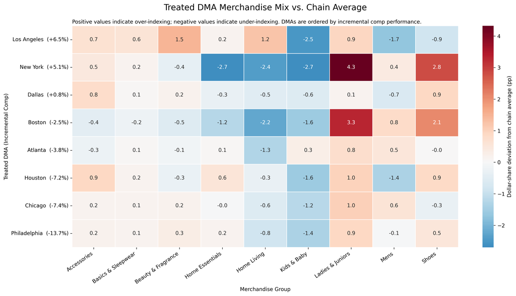

Merchandise dollar-share deviation from the chain average, expressed in percentage points.

## Does Merchandise Mix Explain Performance Differences?

Across all 28 treated-DMA pairs, merchandise mix distance has only a weak positive relationship with the absolute difference in incremental comp performance.

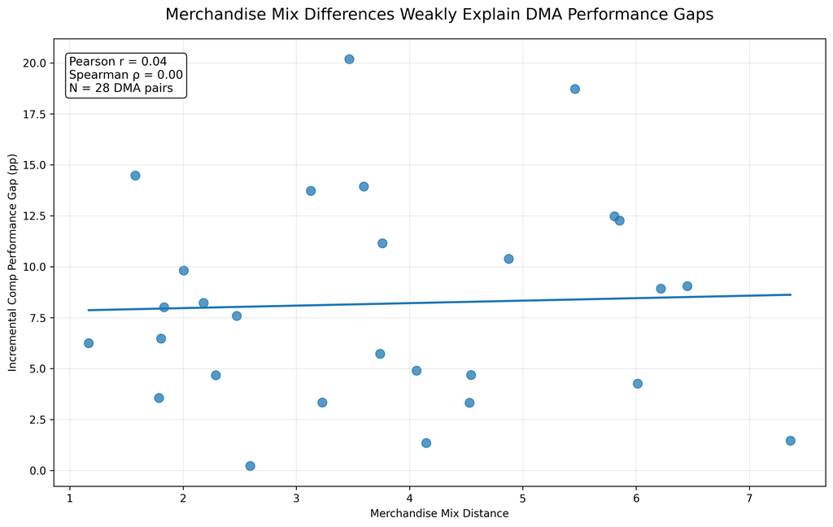

Each point represents one unique pair of treated DMAs. Larger merchandise distance indicates more different merchandise composition.

**Interpretation:** Increasing merchandise dissimilarity does not reliably correspond to increasing performance dissimilarity. Merchandise composition may contribute to local market performance, but it does not appear sufficient to explain the large differences observed across treated markets.

## Closest Merchandise Peer Comparisons

Each treated DMA is matched to the treated market with the most similar merchandise composition. If merchandise mix were a primary explanation for cross-market performance differences, these nearest merchandise peers would generally be expected to exhibit relatively similar outcomes.

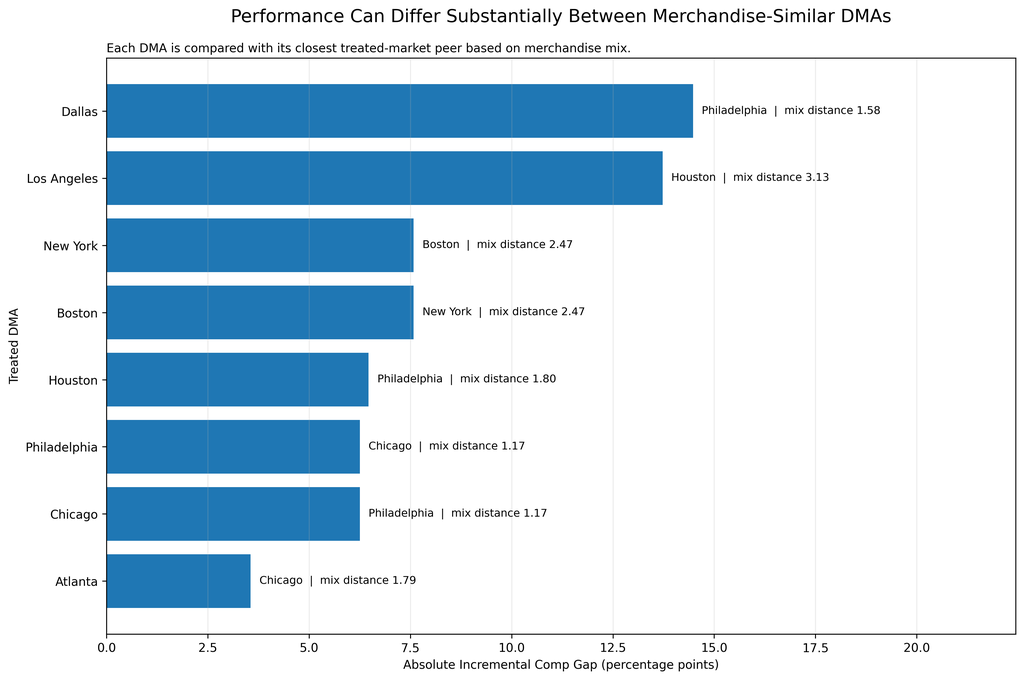

Absolute incremental comp difference between each treated DMA and its closest treated merchandise-mix peer.

## Treated DMA Merchandise & Performance Summary

This table combines merchandise composition, nearest merchandise peer, merchandise distance, and traffic performance into a single treated-market view.

| DMA | Ladies & Juniors | Mens | Shoes | Home Essentials | Home Living | Basics | Kids & Baby | Accessories | Beauty | Closest Mix Peer | Mix Distance | Incremental Comp | Closest DMA Comp | Performance Gap | BSTS Lift | BSTS Gap |
| --- | --- | --- | --- | --- | --- | --- | --- | --- | --- | --- | --- | --- | --- | --- | --- | --- |
| Los Angeles | 17.3% | 14.1% | 9.6% | 11.8% | 11.9% | 9.6% | 7.9% | 8.6% | 9.3% | Houston | 3.128644 | +6.5% | -7.2% | 13.7 pp | +7.0% | 13.9 pp |
| New York | 20.7% | 16.1% | 13.2% | 8.9% | 8.3% | 9.1% | 7.8% | 8.4% | 7.4% | Boston | 2.474053 | +5.1% | -2.5% | 7.6 pp | +5.4% | 7.8 pp |
| Dallas | 16.5% | 15.1% | 11.3% | 11.3% | 10.2% | 9.0% | 9.9% | 8.7% | 8.0% | Philadelphia | 1.577914 | +0.8% | -13.7% | 14.5 pp | +0.8% | 12.9 pp |
| Boston | 19.7% | 16.6% | 12.5% | 10.4% | 8.4% | 8.7% | 8.9% | 7.5% | 7.3% | New York | 2.474053 | -2.5% | +5.1% | 7.6 pp | -2.5% | 7.8 pp |
| Atlanta | 17.2% | 16.3% | 10.4% | 11.7% | 9.4% | 9.0% | 10.7% | 7.6% | 7.7% | Chicago | 1.786251 | -3.8% | -7.4% | 3.6 pp | -3.6% | 3.3 pp |
| Houston | 17.4% | 14.4% | 11.3% | 12.2% | 10.4% | 9.1% | 8.9% | 8.8% | 7.6% | Philadelphia | 1.804254 | -7.2% | -13.7% | 6.5 pp | -7.0% | 5.1 pp |
| Chicago | 17.4% | 16.4% | 10.1% | 11.6% | 10.1% | 9.1% | 9.2% | 8.1% | 8.0% | Philadelphia | 1.166856 | -7.4% | -13.7% | 6.3 pp | -6.9% | 5.2 pp |
| Philadelphia | 17.3% | 15.7% | 11.0% | 11.8% | 9.8% | 9.1% | 9.1% | 8.1% | 8.2% | Chicago | 1.166856 | -13.7% | -7.4% | 6.3 pp | -12.1% | 5.2 pp |

## Key Takeaways

**1. Merchandise mix differs across markets.** Treated DMAs exhibit identifiable over- and under-indexing across major merchandise groups.

**2. Similar merchandise does not consistently imply similar traffic performance.** Several highly merchandise-similar treated markets exhibit materially different incremental comp and BSTS outcomes.

**3. Merchandise distance has weak explanatory relationship with performance distance.** Pairwise correlations are low for both incremental comp and BSTS relative lift.

**4. Merchandise mix therefore appears insufficient to explain observed DMA performance heterogeneity.** The remaining variation is consistent with the presence of additional market-level factors not captured by the variables currently available in the analysis.

### Analytical Limitations

This analysis is descriptive and diagnostic rather than a causal test of merchandise assortment. Merchandise sales can themselves respond to traffic and marketing activity, creating simultaneity between merchandise performance and traffic. Pairwise DMA observations are also not independent, because each treated DMA appears in multiple comparisons.

Results should therefore be interpreted as evidence about whether observed merchandise composition can explain the cross-market pattern in traffic outcomes, rather than as an estimate of the causal effect of merchandise assortment on traffic.

Marketing Incrementality | DMA Merchandise Mix Diagnostics